# Sta112FS 18. CLT based inference, Pt. 3

Dr. Çetinkaya-Rundel

November 10, 2015

# Today’s agenda

## Today’s agenda

- Inference for a proportion
- Inference for difference in two proportions
- Inference for regression
- Testing errors
- **Due Thursday:** HW 3

# Inference for a proportion

## Data

2010 GSS:

```r
gss <- read.csv("https://stat.duke.edu/~mc301/data/gss2010.csv")
```

- Data dictionary at https://gssdataexplorer.norc.org/variables/vfilter
- Note that not all questions are asked every year

## Hypothesis testing for a proportion

Another question on the survey is “Do you think the use of marijuana should be made legal or not?”. Do these data convincing evidence that majority of Americans think that the use of marijuana should **not** be legal? Note that the variable of interest in the dataset is `grass`.

```r
grass_summ <- gss %>%
  filter(!is.na(grass)) %>%
  summarise(x = sum(grass == "NOT LEGAL"), n = length(grass), p_hat = x / n)
grass_summ
```

```
##     x    n     p_hat
## 1 656 1259 0.5210485
```

What are the hypotheses?

Let $p$ represent people who do **not** think marijuana should be legalized.

$$H_0: p = 0.5$$
$$H_A: p > 0.5$$

## Calculating the test statistic

$$\hat{p} \sim N\left(mean = p, SE = \sqrt{\frac{p (1-p)}{n}} \right)$$
$$Z = \frac{obs - null}{SE}$$

```r
se <- sqrt(0.5 * 0.5 / grass_summ$n)
(z <- (grass_summ$p_hat - 0.5) / se)
```

```
## [1] 1.493699
```

## p-value

p-value = P(observed or more extreme outcome | $H_0$ true)

```r
pnorm(z, lower.tail = FALSE)
```

```
## [1] 0.06762719
```

Assuming $\alpha = 0.05$, what is the conclusion of the hypothesis test?

## Equivalency to a confidence interval

What is the equivalent confidence level to this hypothesis test? At this level would you expect a confidence interval to include the null value?

## Confidence interval for a proportion

$$point~estimate \pm critical~value \times SE$$

```r
z_star <- qnorm(0.95)
se <- sqrt(0.52 * (1 - 0.52) / grass_summ$n)
pt_est <- grass_summ$p_hat
round(pt_est + c(-1,1) * z_star * se, 3)
```

```
## [1] 0.498 0.544
```

Interpret this interval in context of the data. Does your confidence interval agree with the result of the hypothesis test?

## In R

Note that `prop.test` function uses a different (equivalent) distribution.

```r
# HT
prop.test(grass_summ$x, grass_summ$n, p = 0.5, alternative = "greater", correct = FALSE)
```

```
##
##  1-sample proportions test without continuity correction
##
## data:  grass_summ$x out of grass_summ$n, null probability 0.5
## X-squared = 2.2311, df = 1, p-value = 0.06763
## alternative hypothesis: true p is greater than 0.5
## 95 percent confidence interval:
##  0.4978702 1.0000000
## sample estimates:
##         p
## 0.5210485
```

```r
# CI
prop.test(grass_summ$x, grass_summ$n, correct = FALSE, conf.level = 0.90)$conf.int
```

```
## [1] 0.4978702 0.5441364
## attr(,"conf.level")
## [1] 0.9
```

# Inference for a difference in two proportions

## Hypothesis test for a difference in two proportions

Is there a difference between the proportions of people who think marijuana should **not** be legalized based on whether they favor or oppose a law which would require a person to obtain a police permit before he or she could buy a gun?

Let $p$ represent people who do **not** think marijuana should be legalized.

$$H_0: p_{pro\_gunlaw} = p_{anti\_gunlaw}$$
$$H_A: p_{pro\_gunlaw} \ne p_{anti\_gunlaw}$$

Note that the variable identifying people who are pro and anti gun laws in the dataset is `gunlaw`.

## Exploratory analysis

What type of visualization would be appropriate for evaluating this research question?

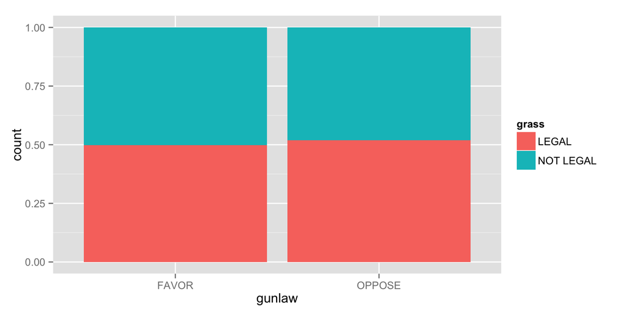

## Summary statistics

```r
gss_gun_grss_summ <- gss_gun_grss %>%
  group_by(gunlaw) %>%
  summarise(x = sum(grass == "NOT LEGAL"), n = length(grass), p_hat = x / n)
gss_gun_grss_summ
```

```
## Source: local data frame [2 x 4]
##
##   gunlaw     x     n     p_hat
##   (fctr) (int) (int)     (dbl)
## 1  FAVOR   211   420 0.5023810
## 2 OPPOSE    65   135 0.4814815
```

## Calculating the test statistic

$$(\hat{p}_1 - \hat{p}_2) \sim N\left(mean = (p_1 - p_2), SE = \sqrt{ \frac{p_1 (1 - p_1)}{n_1} + \frac{p_2 (1 - p_2)}{n_2} } \right)$$
$$Z = \frac{obs - null}{SE}$$

## Standard error under the null

We need to find a reasonable value for $p_1$ and $p_2$ that are equal to each other, and that make sense in the context of these data?

## Pooled proportion

```r
total_suc <- sum(gss_gun_grss_summ$x)
total_n <- sum(gss_gun_grss_summ$n)
(p_pool <- total_suc / total_n)
```

```
## [1] 0.4972973
```

## Calculating the test statistic

```r
se <- sqrt( (p_pool * (1-p_pool))/gss_gun_grss_summ$n[1] +
              (p_pool * (1-p_pool))/gss_gun_grss_summ$n[2] )
(z <- ((gss_gun_grss_summ$p_hat[1] - gss_gun_grss_summ$p_hat[2]) - 0) / se)
```

```
## [1] 0.4224902
```

## p-value

p-value = P(observed or more extreme outcome | $H_0$ true)

```r
pnorm(z, lower.tail= FALSE) * 2
```

```
## [1] 0.6726672
```

Assuming $\alpha = 0.05$, what is the conclusion of the hypothesis test?

## Confidence interval

What is the equivalent confidence level to this hypothesis test? At this level would you expect a confidence interval to include 0?

## Confidence interval for a difference in proportions

$$point~estimate \pm critical~value \times SE$$

The only difference is that SE is calculated using the sample proportions, and not the pooled proportion.

## In R

```r
prop.test(x = c(gss_gun_grss_summ$x[1], gss_gun_grss_summ$x[2]),
          n = c(gss_gun_grss_summ$n[1], gss_gun_grss_summ$n[2]), correct = FALSE)
```

```
##
##  2-sample test for equality of proportions without continuity
##  correction
##
## data:  c(gss_gun_grss_summ$x[1], gss_gun_grss_summ$x[2]) out of c(gss_gun_grss_summ$n[1], gss_gun_grss_summ$n[2])
## X-squared = 0.1785, df = 1, p-value = 0.6727
## alternative hypothesis: two.sided
## 95 percent confidence interval:
##  -0.07600556  0.11780450
## sample estimates:
##    prop 1    prop 2
## 0.5023810 0.4814815
```

# Recap

## Recap

- We now have been introduced to both simulation based and CLT based methods for statistical inference.
- For most simulation based methods you wrote your own code, for CLT based methods we introduced some built in functions.
- Take away message: If certain conditions are met CLT based methods may be used for statistical inference. To do so, we would need to know how the standard error is calculated for the given sample statistic of interest.
- What you should know:
  - What does standard error mean?
  - What does the p-value mean?
  - How do we make decisions based on the p-value?

## in R

- numerical data - `t.test`
  - testing for one mean: $H_0: \mu_x = \mu_0$
  - comparing two means (groups `1` and `2`): $H_0: \mu_1 = \mu_2$
- categorical data - `prop.test`
  - testing for one proportion: $H_0: p_x = p_0$
  - comparing two proportions (groups `1` and `2`): $H_0: p_1 = p_2$

# Inference for regression

## Test your vocabulary

The GSS gives the following 10 question vocabulary test:

1. SPACE (school, noon, captain, room, board, don’t know)
2. BROADEN (efface, make level, elapse, embroider, widen, don’t know)
3. EMANATE (populate, free, prominent, rival, come, don’t know)
4. EDIBLE (auspicious, eligible, fit to eat, sagacious, able to speak, don’t know)
5. ANIMOSITY (hatred, animation, disobedience, diversity, friendship, don’t know)
6. PACT (puissance, remonstrance, agreement, skillet, pressure, don’t know)
7. CLOISTERED (miniature, bunched, arched, malady, secluded, don’t know)
8. CAPRICE (value, a star, grimace, whim, inducement, don’t know)
9. ACCUSTOM (disappoint, customary, encounter, get used to, business, don’t know)
10. ALLUSION (reference, dream, eulogy, illusion, aria, don’t know)

## Distribution of scores on vocabulary test

The variable of interest is `wordsum`:

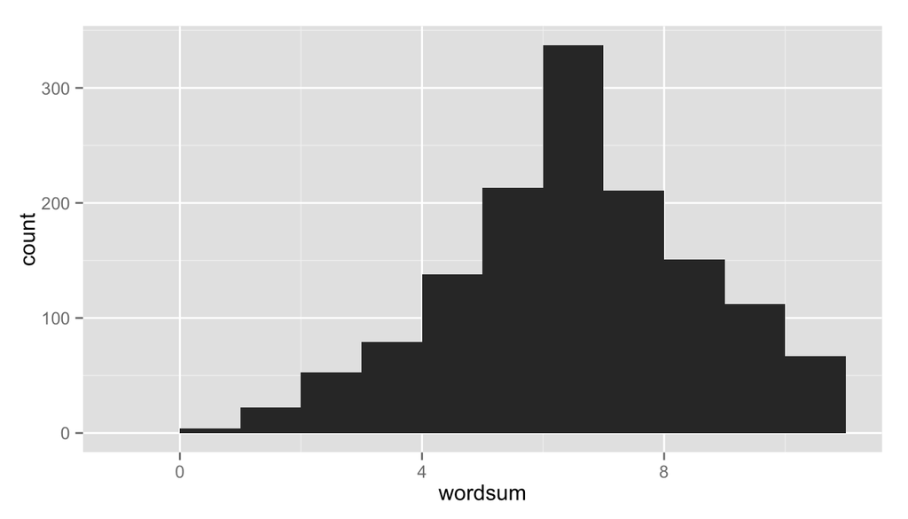

```r
ggplot(data = gss, aes(x = wordsum)) +
  geom_histogram(binwidth = 1)
```

## Inference for regression with single predictor

Number of words correct in a vocabulary test (0 - 10) vs. age:

```r
vocab_age <- lm(wordsum ~ age, data = gss)
summary(vocab_age)
```

```
##
## Call:
## lm(formula = wordsum ~ age, data = gss)
##
## Residuals:
##     Min      1Q  Median      3Q     Max
## -6.1186 -1.1859  0.0562  1.2713  4.3251
##
## Coefficients:
##             Estimate Std. Error t value Pr(>|t|)
## (Intercept) 5.392481   0.159257  33.860  < 2e-16 ***
## age         0.013447   0.003132   4.294 1.88e-05 ***
## ---
## Signif. codes:  0 '***' 0.001 '**' 0.01 '*' 0.05 '.' 0.1 ' ' 1
##
## Residual standard error: 2.053 on 1383 degrees of freedom
##   (659 observations deleted due to missingness)
## Multiple R-squared:  0.01315,    Adjusted R-squared:  0.01244
## F-statistic: 18.44 on 1 and 1383 DF,  p-value: 1.88e-05
```

## Hypothesis test for a slope

$H_0: \beta_{age} = 0$, Slope of age is 0

$H_A: \beta_{age} \ne 0$, Slope of age is different than 0

p-value = 1.88e-05 $\rightarrow$ Reject $H_0$ at 5% significance level.

The data provide convincing evidence that the slope of age is different than 0 for predicting score on vocabulary test.

## Confidence interval for a slope

```r
confint(vocab_age, level = 0.95)
```

```
##                   2.5 %    97.5 %
## (Intercept) 5.080070478 5.7048924
## age         0.007303302 0.0195906
```

We are 95% confident that for each year a person is older their vocabulary score is expected to be higher, on average, by 0.0073 to 0.0196 points.

## Inference for regression with multiple predictors

Number of words correct in a vocabulary test (0 - 10) vs. age + unemployed over the last 10 years:

```r
vocab_age_unemp <- lm(wordsum ~ age + unemp, data = gss)
summary(vocab_age_unemp)
```

```
##
## Call:
## lm(formula = wordsum ~ age + unemp, data = gss)
##
## Residuals:
##     Min      1Q  Median      3Q     Max
## -6.1105 -1.2748  0.0904  1.3782  4.4321
##
## Coefficients:
##              Estimate Std. Error t value Pr(>|t|)
## (Intercept)  5.124384   0.266168  19.252  < 2e-16 ***
## age          0.018261   0.004657   3.921 9.64e-05 ***
## unempYES    -0.049498   0.174337  -0.284    0.777
## ---
## Signif. codes:  0 '***' 0.001 '**' 0.01 '*' 0.05 '.' 0.1 ' ' 1
##
## Residual standard error: 2.148 on 734 degrees of freedom
##   (1307 observations deleted due to missingness)
## Multiple R-squared:  0.0248, Adjusted R-squared:  0.02215
## F-statistic: 9.335 on 2 and 734 DF,  p-value: 9.926e-05
```

## Hypothesis test for multiple slopes

**Age:**

$H_0: \beta_{age} = 0$, Slope of age is 0, given that unemployment is in the model $H_A: \beta_{age} \ne 0$, Slope of age is not 0, given that unemployment is in the model

p-value = 9.64e-05 $\rightarrow$ Reject $H_0$ at 5% significance level. The data provide convincing evidence that the slope of age is different than 0 for predicting score on vocabulary test, given that unemployment is in the model.

**Unemployment:**

$H_0: \beta_{unempYES} = 0$, Slope of unemployment is 0, given that age is in the model \ $H_A: \beta_{unempYES} \ne 0$, Slope of unemployment is not 0, given that age is in the model

p-value = 0.777 $\rightarrow$ Fail to reject $H_0$ at 5% significance level. The data do not provide convincing evidence that the slope of unemployment is different than 0 for predicting score on vocabulary test, given that age is in the model.

## Confidence interval multiple slopes

```r
confint(vocab_age_unemp, level = 0.95)
```

```
##                    2.5 %     97.5 %
## (Intercept)  4.601842116 5.64692636
## age          0.009117995 0.02740331
## unempYES    -0.391757193 0.29276161
```

All else held constant (i.e. given no change in unemployment status), we are 95% confident that for each year a person is older their vocabulary score is expected to be higher, on average, by 0.0091 to 0.0274 points.

Interpret the confidence interval for the slope of unemployment.

## What else can we do with these p-values?

Model selection based on p-value method:

- Backwards elimination: Remove the variable with the highest p-value, re-fit, repeat until all variables are significant at the chosen significance level.
- Forward selection: Start with the variable with the lowest p-value, re-fit, repeat until all no more significant variables left at the chosen sigificance level.

This is used in literature, but is not really recommended!

- Relies on arbitraty significance level cutoff
- Multiple testing!

Instead use adjusted $R^2$, or AIC, or other crieterion based model selection.

# Testing errors

## Testing errors

- Type 1: Reject $H_0$ when you shouldn’t have
  - P(Type 1 error) = $\alpha$
- Type 2: Fail to reject $H_0$ when you should have
  - P(Type 2 error) is harder to calculate, but increases as $\alpha$ decreases

In a court of law

$H_0$: Defendant is innocent

$H_A$: Defendant is guilty

Which is worse: Type 1 or Type 2 error?